# 1. Loops: while, for, repeat.

## 1.1 Qué es un loop?

- Un bucle o ciclo, en programación, es una secuencia que ejecuta repetidas veces por una instrucción/un trozo de código, hasta que la condición asignada a dicho bucle deja de cumplirse. Definición tomada de: https://es.wikipedia.org
- Los loops nos permiten iterar procesos y funciones a un mismo objeto.
- Un loop nos puede ayudar a ahorrar muchas líneas de código en nuestro editor de sintaxis (script).

## 1.2 Tipos de loop

- for
- while
- repeat

## 1.2 Estructura de un loop

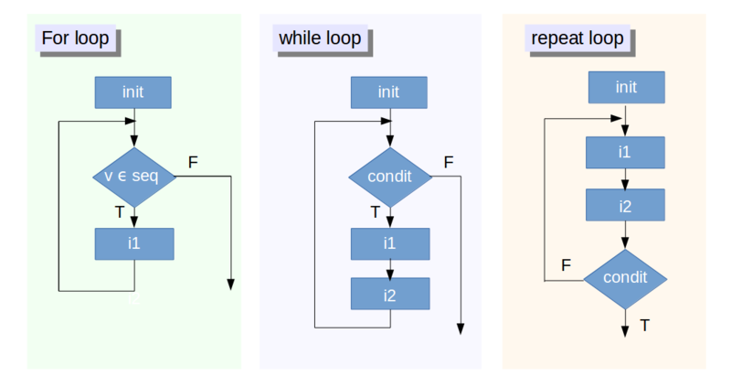

Tomado de: https://www.datacamp.com

```
elementos para iterar: vector con elementos a iterar la sentencia del loop
sentencia: las acciones que se realizan dentro del loop
condicional: control de flujo para filtrar los elementos que cumplan la condición
```

### 1.3. Veamos un ejemplo de for

```r
datos_vio
```

| cod_mpio | violencia_2014 | violencia_2015 | violencia_2016 | violencia_2017 | violencia_2018 | violencia_2019 |
| --- | --- | --- | --- | --- | --- | --- |
| 5001 | 0.05 | 0.09 | 0.02 | 0.03 | 0.01 | 0.01 |
| 5002 | 0.07 | 0.05 | 0.04 | 0.06 | 0.02 | 0.02 |
| 5003 | 0.06 | 0.03 | 0.03 | 0.03 | 0.04 | 0.02 |
| 5004 | 0.03 | 0.06 | 0.02 | 0.01 | 0.05 | 0.03 |
| 5005 | 0.04 | 0.03 | 0.03 | 0.04 | 0.07 | 0.03 |
| 5006 | 0.03 | 0.01 | 0.00 | 0.01 | 0.01 | 0.01 |

```r
for(i in 2:ncol(datos_vio)){
    datos_vio[,i] <- datos_vio[,i]*100
}
```

[figure not shown]

# 2. Controles de flujo (if, else, next, breack)

Los condicionales if y else los usamos para indicarle a R dentro de un loop que queremos que se aplique el statement o la sentencia solo a los elementos que cumplen la condición y a para los demás elementos los pasa por alto.

# 3. Funciones apply, lapply y sapply

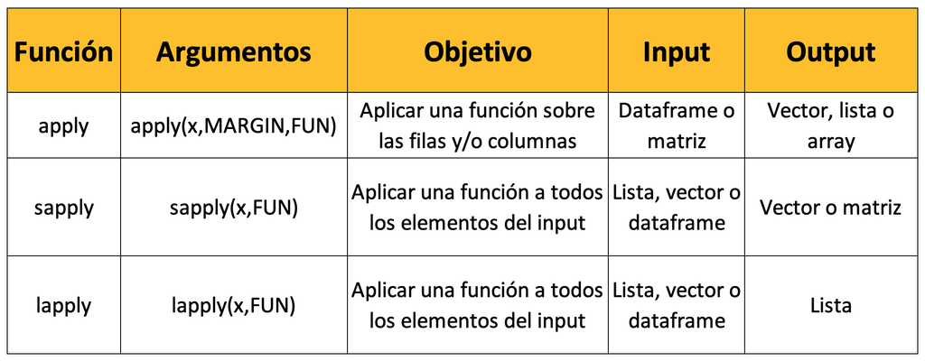

# apply()

Podemos usar esta función para aplicar operaciones a filas y/o columnas de un dataframe. Como resultado obtenemos un objeto de tipo vector, lista o array. La función tiene tres argumentos, X = objeto, MARGIN = 1 si quiero hacer las operaciones por filas y a 2 si quiero hacer las operaciones por columnas y el argumento FUN = a la función que quiero aplicarles a las filas y/o columnas. (ver imagen)

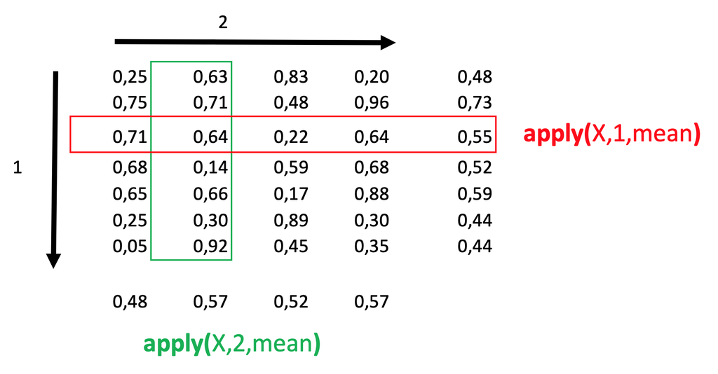

# lapply() y sapply()

Podemos usar `lapply()` para aplicar operaciones a las columnas de un dataframe, los elementos de un vector o los elementos de una lista. Como resultado obtenemos una lista.

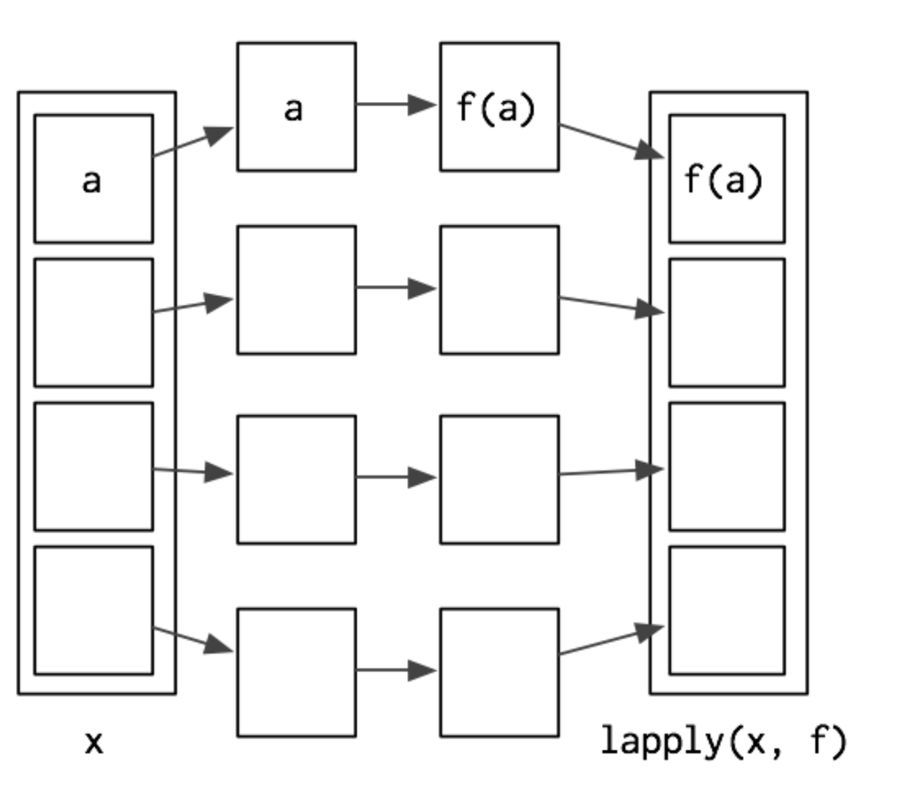

Tomado de: http://adv-r.had.co.nz/Functionals.html